# Risk Factor Analysis

## Outcome Variable

**Outcome Variable:** wasted

## Predictor Variables

**Intervention Variable:** month

**Adjustment Set:**

unadjusted

## Stratifying Variables

The analysis was stratified on these variable(s):

- agecat
- studyid
- country

## Data Summary

| agecat | studyid | country | month | wasted | n_cell | n |
| --- | --- | --- | --- | --- | --- | --- |
| Birth | ki0047075b-MAL-ED | BANGLADESH | 1 | 0 | 18 | 241 |
| Birth | ki0047075b-MAL-ED | BANGLADESH | 1 | 1 | 1 | 241 |
| Birth | ki0047075b-MAL-ED | BANGLADESH | 2 | 0 | 16 | 241 |
| Birth | ki0047075b-MAL-ED | BANGLADESH | 2 | 1 | 5 | 241 |
| Birth | ki0047075b-MAL-ED | BANGLADESH | 3 | 0 | 21 | 241 |
| Birth | ki0047075b-MAL-ED | BANGLADESH | 3 | 1 | 4 | 241 |
| Birth | ki0047075b-MAL-ED | BANGLADESH | 4 | 0 | 17 | 241 |
| Birth | ki0047075b-MAL-ED | BANGLADESH | 4 | 1 | 4 | 241 |
| Birth | ki0047075b-MAL-ED | BANGLADESH | 5 | 0 | 18 | 241 |
| Birth | ki0047075b-MAL-ED | BANGLADESH | 5 | 1 | 2 | 241 |
| Birth | ki0047075b-MAL-ED | BANGLADESH | 6 | 0 | 8 | 241 |
| Birth | ki0047075b-MAL-ED | BANGLADESH | 6 | 1 | 0 | 241 |
| Birth | ki0047075b-MAL-ED | BANGLADESH | 7 | 0 | 16 | 241 |
| Birth | ki0047075b-MAL-ED | BANGLADESH | 7 | 1 | 5 | 241 |
| Birth | ki0047075b-MAL-ED | BANGLADESH | 8 | 0 | 19 | 241 |
| Birth | ki0047075b-MAL-ED | BANGLADESH | 8 | 1 | 3 | 241 |
| Birth | ki0047075b-MAL-ED | BANGLADESH | 9 | 0 | 13 | 241 |
| Birth | ki0047075b-MAL-ED | BANGLADESH | 9 | 1 | 7 | 241 |
| Birth | ki0047075b-MAL-ED | BANGLADESH | 10 | 0 | 20 | 241 |
| Birth | ki0047075b-MAL-ED | BANGLADESH | 10 | 1 | 3 | 241 |
| Birth | ki0047075b-MAL-ED | BANGLADESH | 11 | 0 | 13 | 241 |
| Birth | ki0047075b-MAL-ED | BANGLADESH | 11 | 1 | 2 | 241 |
| Birth | ki0047075b-MAL-ED | BANGLADESH | 12 | 0 | 22 | 241 |
| Birth | ki0047075b-MAL-ED | BANGLADESH | 12 | 1 | 4 | 241 |
| Birth | ki0047075b-MAL-ED | BRAZIL | 1 | 0 | 7 | 183 |
| Birth | ki0047075b-MAL-ED | BRAZIL | 1 | 1 | 2 | 183 |
| Birth | ki0047075b-MAL-ED | BRAZIL | 2 | 0 | 18 | 183 |
| Birth | ki0047075b-MAL-ED | BRAZIL | 2 | 1 | 1 | 183 |
| Birth | ki0047075b-MAL-ED | BRAZIL | 3 | 0 | 17 | 183 |
| Birth | ki0047075b-MAL-ED | BRAZIL | 3 | 1 | 0 | 183 |

[output cut: 1626 more lines]

The following strata were considered:

- agecat: 24 months, studyid: ki0047075b-MAL-ED, country: BANGLADESH
- agecat: 24 months, studyid: ki0047075b-MAL-ED, country: BRAZIL
- agecat: 24 months, studyid: ki0047075b-MAL-ED, country: INDIA
- agecat: 24 months, studyid: ki0047075b-MAL-ED, country: NEPAL
- agecat: 24 months, studyid: ki0047075b-MAL-ED, country: PERU
- agecat: 24 months, studyid: ki0047075b-MAL-ED, country: SOUTH AFRICA
- agecat: 24 months, studyid: ki0047075b-MAL-ED, country: TANZANIA, UNITED REPUBLIC OF
- agecat: 24 months, studyid: ki1000108-CMC-V-BCS-2002, country: INDIA
- agecat: 24 months, studyid: ki1000108-IRC, country: INDIA
- agecat: 24 months, studyid: ki1017093-NIH-Birth, country: BANGLADESH
- agecat: 24 months, studyid: ki1066203-TanzaniaChild2, country: TANZANIA, UNITED REPUBLIC OF
- agecat: 24 months, studyid: ki1113344-GMS-Nepal, country: NEPAL
- agecat: 24 months, studyid: ki1114097-CMIN, country: BANGLADESH
- agecat: 24 months, studyid: ki1114097-CMIN, country: GUINEA-BISSAU
- agecat: 24 months, studyid: ki1114097-CMIN, country: PERU
- agecat: 24 months, studyid: ki1114097-CONTENT, country: PERU
- agecat: 24 months, studyid: ki1119695-PROBIT, country: BELARUS
- agecat: 24 months, studyid: ki1126311-ZVITAMBO, country: ZIMBABWE
- agecat: 24 months, studyid: ki1148112-LCNI-5, country: MALAWI
- agecat: 24 months, studyid: kiGH5241-JiVitA-3, country: BANGLADESH
- agecat: 24 months, studyid: kiGH5241-JiVitA-4, country: BANGLADESH
- agecat: 6 months, studyid: ki0047075b-MAL-ED, country: BANGLADESH
- agecat: 6 months, studyid: ki0047075b-MAL-ED, country: BRAZIL
- agecat: 6 months, studyid: ki0047075b-MAL-ED, country: INDIA
- agecat: 6 months, studyid: ki0047075b-MAL-ED, country: NEPAL
- agecat: 6 months, studyid: ki0047075b-MAL-ED, country: PERU
- agecat: 6 months, studyid: ki0047075b-MAL-ED, country: SOUTH AFRICA
- agecat: 6 months, studyid: ki0047075b-MAL-ED, country: TANZANIA, UNITED REPUBLIC OF
- agecat: 6 months, studyid: ki1000108-CMC-V-BCS-2002, country: INDIA
- agecat: 6 months, studyid: ki1000108-IRC, country: INDIA
- agecat: 6 months, studyid: ki1000109-EE, country: PAKISTAN
- agecat: 6 months, studyid: ki1000109-ResPak, country: PAKISTAN
- agecat: 6 months, studyid: ki1000304b-SAS-CompFeed, country: INDIA
- agecat: 6 months, studyid: ki1000304b-SAS-FoodSuppl, country: INDIA
- agecat: 6 months, studyid: ki1017093-NIH-Birth, country: BANGLADESH
- agecat: 6 months, studyid: ki1066203-TanzaniaChild2, country: TANZANIA, UNITED REPUBLIC OF
- agecat: 6 months, studyid: ki1112895-Guatemala BSC, country: GUATEMALA
- agecat: 6 months, studyid: ki1113344-GMS-Nepal, country: NEPAL
- agecat: 6 months, studyid: ki1114097-CMIN, country: BANGLADESH
- agecat: 6 months, studyid: ki1114097-CMIN, country: BRAZIL
- agecat: 6 months, studyid: ki1114097-CMIN, country: GUINEA-BISSAU
- agecat: 6 months, studyid: ki1114097-CMIN, country: PERU
- agecat: 6 months, studyid: ki1114097-CONTENT, country: PERU
- agecat: 6 months, studyid: ki1119695-PROBIT, country: BELARUS
- agecat: 6 months, studyid: ki1126311-ZVITAMBO, country: ZIMBABWE
- agecat: 6 months, studyid: ki1148112-LCNI-5, country: MALAWI
- agecat: 6 months, studyid: kiGH5241-JiVitA-3, country: BANGLADESH
- agecat: 6 months, studyid: kiGH5241-JiVitA-4, country: BANGLADESH
- agecat: Birth, studyid: ki0047075b-MAL-ED, country: BANGLADESH
- agecat: Birth, studyid: ki0047075b-MAL-ED, country: BRAZIL
- agecat: Birth, studyid: ki0047075b-MAL-ED, country: INDIA
- agecat: Birth, studyid: ki0047075b-MAL-ED, country: NEPAL
- agecat: Birth, studyid: ki0047075b-MAL-ED, country: PERU
- agecat: Birth, studyid: ki0047075b-MAL-ED, country: SOUTH AFRICA
- agecat: Birth, studyid: ki0047075b-MAL-ED, country: TANZANIA, UNITED REPUBLIC OF
- agecat: Birth, studyid: ki1000108-CMC-V-BCS-2002, country: INDIA
- agecat: Birth, studyid: ki1000108-IRC, country: INDIA
- agecat: Birth, studyid: ki1000109-EE, country: PAKISTAN
- agecat: Birth, studyid: ki1000109-ResPak, country: PAKISTAN
- agecat: Birth, studyid: ki1000304b-SAS-CompFeed, country: INDIA
- agecat: Birth, studyid: ki1017093-NIH-Birth, country: BANGLADESH
- agecat: Birth, studyid: ki1114097-CMIN, country: BANGLADESH
- agecat: Birth, studyid: ki1114097-CMIN, country: BRAZIL
- agecat: Birth, studyid: ki1114097-CMIN, country: PERU
- agecat: Birth, studyid: ki1114097-CONTENT, country: PERU
- agecat: Birth, studyid: ki1119695-PROBIT, country: BELARUS
- agecat: Birth, studyid: ki1126311-ZVITAMBO, country: ZIMBABWE
- agecat: Birth, studyid: kiGH5241-JiVitA-3, country: BANGLADESH
- agecat: Birth, studyid: kiGH5241-JiVitA-4, country: BANGLADESH

### Dropped Strata

Some strata were dropped due to rare outcomes:

- agecat: Birth, studyid: ki0047075b-MAL-ED, country: BANGLADESH
- agecat: Birth, studyid: ki0047075b-MAL-ED, country: BRAZIL
- agecat: Birth, studyid: ki0047075b-MAL-ED, country: INDIA
- agecat: Birth, studyid: ki0047075b-MAL-ED, country: NEPAL
- agecat: Birth, studyid: ki0047075b-MAL-ED, country: PERU
- agecat: Birth, studyid: ki0047075b-MAL-ED, country: SOUTH AFRICA
- agecat: Birth, studyid: ki0047075b-MAL-ED, country: TANZANIA, UNITED REPUBLIC OF
- agecat: Birth, studyid: ki1000108-CMC-V-BCS-2002, country: INDIA
- agecat: Birth, studyid: ki1000108-IRC, country: INDIA
- agecat: Birth, studyid: ki1000109-EE, country: PAKISTAN
- agecat: Birth, studyid: ki1000109-ResPak, country: PAKISTAN
- agecat: Birth, studyid: ki1000304b-SAS-CompFeed, country: INDIA
- agecat: Birth, studyid: ki1017093-NIH-Birth, country: BANGLADESH
- agecat: Birth, studyid: ki1114097-CMIN, country: BANGLADESH
- agecat: Birth, studyid: ki1114097-CMIN, country: BRAZIL
- agecat: Birth, studyid: ki1114097-CMIN, country: PERU
- agecat: Birth, studyid: ki1114097-CONTENT, country: PERU
- agecat: Birth, studyid: kiGH5241-JiVitA-4, country: BANGLADESH
- agecat: 6 months, studyid: ki0047075b-MAL-ED, country: BANGLADESH
- agecat: 6 months, studyid: ki0047075b-MAL-ED, country: BRAZIL
- agecat: 6 months, studyid: ki0047075b-MAL-ED, country: INDIA
- agecat: 6 months, studyid: ki0047075b-MAL-ED, country: NEPAL
- agecat: 6 months, studyid: ki0047075b-MAL-ED, country: PERU
- agecat: 6 months, studyid: ki0047075b-MAL-ED, country: SOUTH AFRICA
- agecat: 6 months, studyid: ki0047075b-MAL-ED, country: TANZANIA, UNITED REPUBLIC OF
- agecat: 6 months, studyid: ki1000108-CMC-V-BCS-2002, country: INDIA
- agecat: 6 months, studyid: ki1000108-IRC, country: INDIA
- agecat: 6 months, studyid: ki1000109-EE, country: PAKISTAN
- agecat: 6 months, studyid: ki1000109-ResPak, country: PAKISTAN
- agecat: 6 months, studyid: ki1000304b-SAS-FoodSuppl, country: INDIA
- agecat: 6 months, studyid: ki1017093-NIH-Birth, country: BANGLADESH
- agecat: 6 months, studyid: ki1066203-TanzaniaChild2, country: TANZANIA, UNITED REPUBLIC OF
- agecat: 6 months, studyid: ki1112895-Guatemala BSC, country: GUATEMALA
- agecat: 6 months, studyid: ki1113344-GMS-Nepal, country: NEPAL
- agecat: 6 months, studyid: ki1114097-CMIN, country: BANGLADESH
- agecat: 6 months, studyid: ki1114097-CMIN, country: BRAZIL
- agecat: 6 months, studyid: ki1114097-CMIN, country: GUINEA-BISSAU
- agecat: 6 months, studyid: ki1114097-CMIN, country: PERU
- agecat: 6 months, studyid: ki1114097-CONTENT, country: PERU
- agecat: 6 months, studyid: ki1148112-LCNI-5, country: MALAWI
- agecat: 6 months, studyid: kiGH5241-JiVitA-4, country: BANGLADESH
- agecat: 24 months, studyid: ki0047075b-MAL-ED, country: BANGLADESH
- agecat: 24 months, studyid: ki0047075b-MAL-ED, country: BRAZIL
- agecat: 24 months, studyid: ki0047075b-MAL-ED, country: INDIA
- agecat: 24 months, studyid: ki0047075b-MAL-ED, country: NEPAL
- agecat: 24 months, studyid: ki0047075b-MAL-ED, country: PERU
- agecat: 24 months, studyid: ki0047075b-MAL-ED, country: SOUTH AFRICA
- agecat: 24 months, studyid: ki0047075b-MAL-ED, country: TANZANIA, UNITED REPUBLIC OF
- agecat: 24 months, studyid: ki1000108-CMC-V-BCS-2002, country: INDIA
- agecat: 24 months, studyid: ki1000108-IRC, country: INDIA
- agecat: 24 months, studyid: ki1017093-NIH-Birth, country: BANGLADESH
- agecat: 24 months, studyid: ki1066203-TanzaniaChild2, country: TANZANIA, UNITED REPUBLIC OF
- agecat: 24 months, studyid: ki1113344-GMS-Nepal, country: NEPAL
- agecat: 24 months, studyid: ki1114097-CMIN, country: BANGLADESH
- agecat: 24 months, studyid: ki1114097-CMIN, country: GUINEA-BISSAU
- agecat: 24 months, studyid: ki1114097-CMIN, country: PERU
- agecat: 24 months, studyid: ki1114097-CONTENT, country: PERU
- agecat: 24 months, studyid: ki1119695-PROBIT, country: BELARUS
- agecat: 24 months, studyid: ki1126311-ZVITAMBO, country: ZIMBABWE
- agecat: 24 months, studyid: ki1148112-LCNI-5, country: MALAWI

## Methods Detail

We’re interested in the causal parameters $E[Y_a]$ for all values of $a \in \mathcal{A}$. These parameters represent the mean outcome if, possibly contrary to fact, we intervened to set all units to have $A=a$. Under the randomization and positivity assumptions, these are identified by the statistical parameters $\psi_a=E_W[E_{Y|A,W}(Y|A=a,W)]$. In addition, we’re interested in the mean of $Y$, $E[Y]$ under no intervention (the observed mean). We will estimate these parameters by using SuperLearner to fit the relevant likelihood factors – $E_{Y|A,W}(Y|A=a,W)$ and $p(A=a|W)$, and then updating our likelihood fit using a joint TMLE.

For unadjusted analyses ($W=\{\}$), initial likelihoods were estimated using Lrnr_glm to estimate the simple $E(Y|A)$ and Lrnr_mean to estimate $p(A)$. For adjusted analyses, a small library containing Lrnr_glmnet, Lrnr_xgboost, and Lrnr_mean was used.

Having estimated these parameters, we will then use the delta method to estimate relative risks and attributable risks relative to a prespecified baseline level of $A$.

# Results Detail

## Results Plots

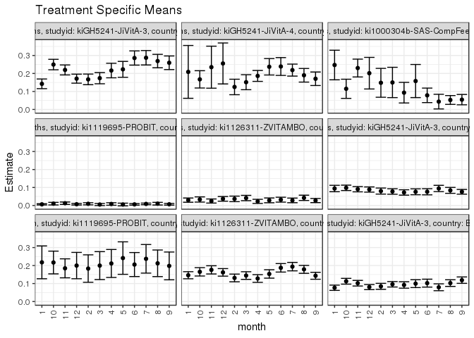

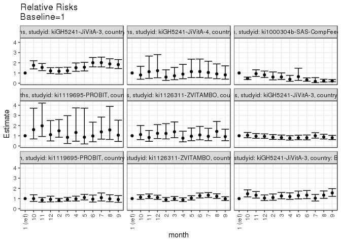

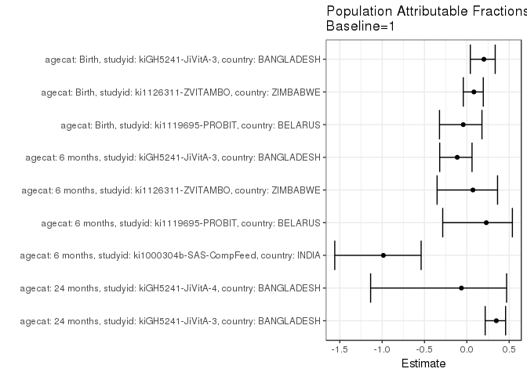

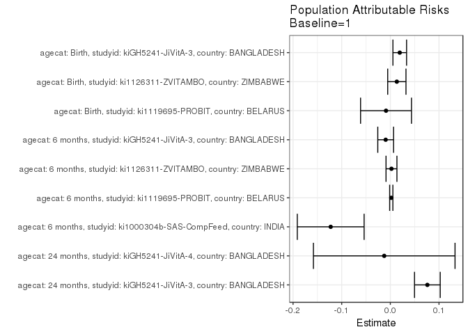

## Results Table

### Parameter: TSM

| agecat | studyid | country | intervention_level | baseline_level | estimate | ci_lower | ci_upper |
| --- | --- | --- | --- | --- | --- | --- | --- |
| Birth | ki1119695-PROBIT | BELARUS | 1 | NA | 0.2177986 | 0.1266018 | 0.3089954 |
| Birth | ki1119695-PROBIT | BELARUS | 2 | NA | 0.1832061 | 0.1067709 | 0.2596413 |
| Birth | ki1119695-PROBIT | BELARUS | 3 | NA | 0.1997919 | 0.1221371 | 0.2774467 |
| Birth | ki1119695-PROBIT | BELARUS | 4 | NA | 0.2115183 | 0.1337556 | 0.2892811 |
| Birth | ki1119695-PROBIT | BELARUS | 5 | NA | 0.2415612 | 0.1512803 | 0.3318421 |
| Birth | ki1119695-PROBIT | BELARUS | 6 | NA | 0.2055611 | 0.1388339 | 0.2722883 |
| Birth | ki1119695-PROBIT | BELARUS | 7 | NA | 0.2374608 | 0.1579282 | 0.3169934 |
| Birth | ki1119695-PROBIT | BELARUS | 8 | NA | 0.2124431 | 0.1385383 | 0.2863478 |
| Birth | ki1119695-PROBIT | BELARUS | 9 | NA | 0.1980198 | 0.1208014 | 0.2752382 |
| Birth | ki1119695-PROBIT | BELARUS | 10 | NA | 0.2169559 | 0.1537285 | 0.2801833 |
| Birth | ki1119695-PROBIT | BELARUS | 11 | NA | 0.1846264 | 0.1318246 | 0.2374283 |
| Birth | ki1119695-PROBIT | BELARUS | 12 | NA | 0.1998681 | 0.1266637 | 0.2730724 |
| Birth | ki1126311-ZVITAMBO | ZIMBABWE | 1 | NA | 0.1462036 | 0.1265219 | 0.1658852 |
| Birth | ki1126311-ZVITAMBO | ZIMBABWE | 2 | NA | 0.1310782 | 0.1095715 | 0.1525850 |
| Birth | ki1126311-ZVITAMBO | ZIMBABWE | 3 | NA | 0.1443396 | 0.1231826 | 0.1654967 |
| Birth | ki1126311-ZVITAMBO | ZIMBABWE | 4 | NA | 0.1280683 | 0.1066711 | 0.1494655 |
| Birth | ki1126311-ZVITAMBO | ZIMBABWE | 5 | NA | 0.1533406 | 0.1299677 | 0.1767135 |
| Birth | ki1126311-ZVITAMBO | ZIMBABWE | 6 | NA | 0.1873805 | 0.1637319 | 0.2110291 |
| Birth | ki1126311-ZVITAMBO | ZIMBABWE | 7 | NA | 0.1939891 | 0.1705995 | 0.2173787 |
| Birth | ki1126311-ZVITAMBO | ZIMBABWE | 8 | NA | 0.1788478 | 0.1568222 | 0.2008735 |
| Birth | ki1126311-ZVITAMBO | ZIMBABWE | 9 | NA | 0.1431962 | 0.1238855 | 0.1625069 |
| Birth | ki1126311-ZVITAMBO | ZIMBABWE | 10 | NA | 0.1651376 | 0.1419016 | 0.1883736 |
| Birth | ki1126311-ZVITAMBO | ZIMBABWE | 11 | NA | 0.1760300 | 0.1531883 | 0.1988717 |
| Birth | ki1126311-ZVITAMBO | ZIMBABWE | 12 | NA | 0.1620017 | 0.1409693 | 0.1830341 |
| Birth | kiGH5241-JiVitA-3 | BANGLADESH | 1 | NA | 0.0765517 | 0.0619340 | 0.0911694 |
| Birth | kiGH5241-JiVitA-3 | BANGLADESH | 2 | NA | 0.0844410 | 0.0678377 | 0.1010442 |
| Birth | kiGH5241-JiVitA-3 | BANGLADESH | 3 | NA | 0.0958816 | 0.0807115 | 0.1110517 |
| Birth | kiGH5241-JiVitA-3 | BANGLADESH | 4 | NA | 0.0920139 | 0.0741921 | 0.1098357 |
| Birth | kiGH5241-JiVitA-3 | BANGLADESH | 5 | NA | 0.0994898 | 0.0775983 | 0.1213813 |
| Birth | kiGH5241-JiVitA-3 | BANGLADESH | 6 | NA | 0.1021898 | 0.0801705 | 0.1242091 |

[output cut: 78 more lines]

### Parameter: E(Y)

| agecat | studyid | country | intervention_level | baseline_level | estimate | ci_lower | ci_upper |
| --- | --- | --- | --- | --- | --- | --- | --- |
| Birth | ki1119695-PROBIT | BELARUS | NA | NA | 0.2089120 | 0.1435514 | 0.2742726 |
| Birth | ki1126311-ZVITAMBO | ZIMBABWE | NA | NA | 0.1595439 | 0.1532229 | 0.1658649 |
| Birth | kiGH5241-JiVitA-3 | BANGLADESH | NA | NA | 0.0958686 | 0.0906699 | 0.1010673 |
| 6 months | ki1000304b-SAS-CompFeed | INDIA | NA | NA | 0.1244378 | 0.0992652 | 0.1496104 |
| 6 months | ki1119695-PROBIT | BELARUS | NA | NA | 0.0082503 | 0.0066012 | 0.0098994 |
| 6 months | ki1126311-ZVITAMBO | ZIMBABWE | NA | NA | 0.0321251 | 0.0283197 | 0.0359306 |
| 6 months | kiGH5241-JiVitA-3 | BANGLADESH | NA | NA | 0.0847478 | 0.0799486 | 0.0895469 |
| 24 months | kiGH5241-JiVitA-3 | BANGLADESH | NA | NA | 0.2185461 | 0.2086586 | 0.2284336 |
| 24 months | kiGH5241-JiVitA-4 | BANGLADESH | NA | NA | 0.1961929 | 0.1827435 | 0.2096424 |

### Parameter: RR

| agecat | studyid | country | intervention_level | baseline_level | estimate | ci_lower | ci_upper |
| --- | --- | --- | --- | --- | --- | --- | --- |
| Birth | ki1119695-PROBIT | BELARUS | 1 | 1 | 1.0000000 | 1.0000000 | 1.0000000 |
| Birth | ki1119695-PROBIT | BELARUS | 2 | 1 | 0.8411721 | 0.6936888 | 1.0200115 |
| Birth | ki1119695-PROBIT | BELARUS | 3 | 1 | 0.9173240 | 0.7512310 | 1.1201392 |
| Birth | ki1119695-PROBIT | BELARUS | 4 | 1 | 0.9711648 | 0.7626993 | 1.2366092 |
| Birth | ki1119695-PROBIT | BELARUS | 5 | 1 | 1.1091035 | 0.8704630 | 1.4131680 |
| Birth | ki1119695-PROBIT | BELARUS | 6 | 1 | 0.9438127 | 0.6616481 | 1.3463084 |
| Birth | ki1119695-PROBIT | BELARUS | 7 | 1 | 1.0902771 | 0.7657046 | 1.5524318 |
| Birth | ki1119695-PROBIT | BELARUS | 8 | 1 | 0.9754108 | 0.6913368 | 1.3762123 |
| Birth | ki1119695-PROBIT | BELARUS | 9 | 1 | 0.9091877 | 0.6383123 | 1.2950122 |
| Birth | ki1119695-PROBIT | BELARUS | 10 | 1 | 0.9961310 | 0.7213143 | 1.3756514 |
| Birth | ki1119695-PROBIT | BELARUS | 11 | 1 | 0.8476934 | 0.6525064 | 1.1012676 |
| Birth | ki1119695-PROBIT | BELARUS | 12 | 1 | 0.9176738 | 0.6801926 | 1.2380688 |
| Birth | ki1126311-ZVITAMBO | ZIMBABWE | 1 | 1 | 1.0000000 | 1.0000000 | 1.0000000 |
| Birth | ki1126311-ZVITAMBO | ZIMBABWE | 2 | 1 | 0.8965461 | 0.7251052 | 1.1085218 |
| Birth | ki1126311-ZVITAMBO | ZIMBABWE | 3 | 1 | 0.9872511 | 0.8090889 | 1.2046448 |
| Birth | ki1126311-ZVITAMBO | ZIMBABWE | 4 | 1 | 0.8759589 | 0.7068071 | 1.0855917 |
| Birth | ki1126311-ZVITAMBO | ZIMBABWE | 5 | 1 | 1.0488161 | 0.8558176 | 1.2853382 |
| Birth | ki1126311-ZVITAMBO | ZIMBABWE | 6 | 1 | 1.2816412 | 1.0656821 | 1.5413641 |
| Birth | ki1126311-ZVITAMBO | ZIMBABWE | 7 | 1 | 1.3268424 | 1.1074748 | 1.5896620 |
| Birth | ki1126311-ZVITAMBO | ZIMBABWE | 8 | 1 | 1.2232795 | 1.0192668 | 1.4681265 |
| Birth | ki1126311-ZVITAMBO | ZIMBABWE | 9 | 1 | 0.9794304 | 0.8095068 | 1.1850227 |
| Birth | ki1126311-ZVITAMBO | ZIMBABWE | 10 | 1 | 1.1295048 | 0.9296452 | 1.3723311 |
| Birth | ki1126311-ZVITAMBO | ZIMBABWE | 11 | 1 | 1.2040060 | 0.9986801 | 1.4515465 |
| Birth | ki1126311-ZVITAMBO | ZIMBABWE | 12 | 1 | 1.1080558 | 0.9190493 | 1.3359323 |
| Birth | kiGH5241-JiVitA-3 | BANGLADESH | 1 | 1 | 1.0000000 | 1.0000000 | 1.0000000 |
| Birth | kiGH5241-JiVitA-3 | BANGLADESH | 2 | 1 | 1.1030577 | 0.8380519 | 1.4518628 |
| Birth | kiGH5241-JiVitA-3 | BANGLADESH | 3 | 1 | 1.2525073 | 0.9797800 | 1.6011499 |
| Birth | kiGH5241-JiVitA-3 | BANGLADESH | 4 | 1 | 1.2019832 | 0.9235799 | 1.5643083 |
| Birth | kiGH5241-JiVitA-3 | BANGLADESH | 5 | 1 | 1.2996415 | 0.9723534 | 1.7370926 |
| Birth | kiGH5241-JiVitA-3 | BANGLADESH | 6 | 1 | 1.3349116 | 0.9963924 | 1.7884408 |

[output cut: 78 more lines]

### Parameter: PAR

| agecat | studyid | country | intervention_level | baseline_level | estimate | ci_lower | ci_upper |
| --- | --- | --- | --- | --- | --- | --- | --- |
| Birth | ki1119695-PROBIT | BELARUS | 1 | NA | -0.0088866 | -0.0612288 | 0.0434557 |
| Birth | ki1126311-ZVITAMBO | ZIMBABWE | 1 | NA | 0.0133404 | -0.0054461 | 0.0321268 |
| Birth | kiGH5241-JiVitA-3 | BANGLADESH | 1 | NA | 0.0193169 | 0.0052738 | 0.0333600 |
| 6 months | ki1000304b-SAS-CompFeed | INDIA | 1 | NA | -0.1226210 | -0.1913269 | -0.0539152 |
| 6 months | ki1119695-PROBIT | BELARUS | 1 | NA | 0.0018924 | -0.0013975 | 0.0051823 |
| 6 months | ki1126311-ZVITAMBO | ZIMBABWE | 1 | NA | 0.0023114 | -0.0088950 | 0.0135179 |
| 6 months | kiGH5241-JiVitA-3 | BANGLADESH | 1 | NA | -0.0096127 | -0.0258142 | 0.0065888 |
| 24 months | kiGH5241-JiVitA-3 | BANGLADESH | 1 | NA | 0.0760960 | 0.0496629 | 0.1025291 |
| 24 months | kiGH5241-JiVitA-4 | BANGLADESH | 1 | NA | -0.0125983 | -0.1581483 | 0.1329518 |

### Parameter: PAF

| agecat | studyid | country | intervention_level | baseline_level | estimate | ci_lower | ci_upper |
| --- | --- | --- | --- | --- | --- | --- | --- |
| Birth | ki1119695-PROBIT | BELARUS | 1 | NA | -0.0425373 | -0.3229664 | 0.1784492 |
| Birth | ki1126311-ZVITAMBO | ZIMBABWE | 1 | NA | 0.0836157 | -0.0420005 | 0.1940886 |
| Birth | kiGH5241-JiVitA-3 | BANGLADESH | 1 | NA | 0.2014933 | 0.0411741 | 0.3350066 |
| 6 months | ki1000304b-SAS-CompFeed | INDIA | 1 | NA | -0.9854004 | -1.5599574 | -0.5397970 |
| 6 months | ki1119695-PROBIT | BELARUS | 1 | NA | 0.2293789 | -0.2849958 | 0.5378530 |
| 6 months | ki1126311-ZVITAMBO | ZIMBABWE | 1 | NA | 0.0719512 | -0.3513528 | 0.3626576 |
| 6 months | kiGH5241-JiVitA-3 | BANGLADESH | 1 | NA | -0.1134272 | -0.3205225 | 0.0611897 |
| 24 months | kiGH5241-JiVitA-3 | BANGLADESH | 1 | NA | 0.3481919 | 0.2166133 | 0.4576703 |
| 24 months | kiGH5241-JiVitA-4 | BANGLADESH | 1 | NA | -0.0642136 | -1.1364466 | 0.4698905 |